# Investigation of the Twitter Account WeRateDogs

### Investigation Overview

In this project, I gathered tweet data in a variety of different sources from the Twitter Account [WeRateDogs](https://twitter.com/dog_rates). The goal is to analyze different characteristics and their contribution towards a tweet going viral.

### Dataset Overview

The cleaned project consists of two DataFrames. One containing information about the popularity of a tweet and the other containg a prediction for the dog breed displayed in the image. Both DataFrames hold information on 1.500+ unique tweets.

###### You can display the code for each plot by simply klicking on it.

### Let's start by checking which dog breed is the most common.

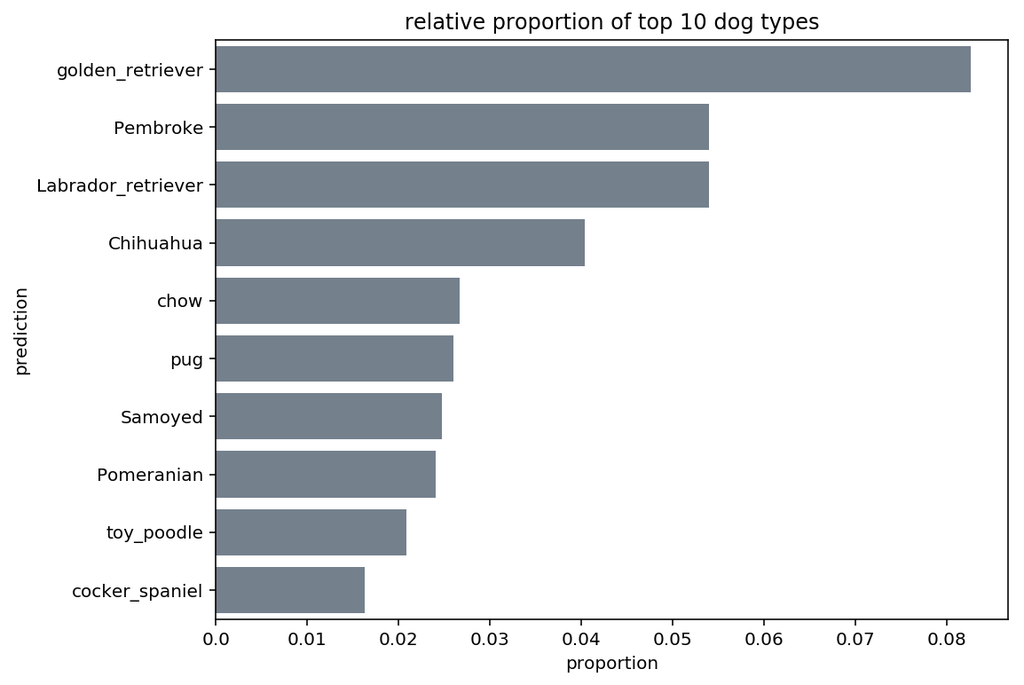

```python
top_predictions = predictions[predictions['confidence_order'] == 1]
# only consider top predictions
n_points = top_predictions.shape[0]
# total number of top predictions
order = top_predictions.prediction.value_counts().head(10).index
# order of top 10 most predicted tog types
max_count = top_predictions.prediction.value_counts().max()
max_prob = max_count / n_points
# probability of most common dog type to define limit of x-axis
tick_probs = np.arange(0, max_prob, 0.01) # arange x-ticks in 0.01 steps

plt.figure(figsize = (8, 6))
sns.countplot(data = top_predictions, y = 'prediction',\
              color = base_color, order=order)
plt.xticks(tick_probs * n_points, tick_probs)
plt.xlabel('proportion')
plt.title('relative proportion of top 10 dog types');
```

### Let's check whether the most tweeted dog breeds are also the most popular

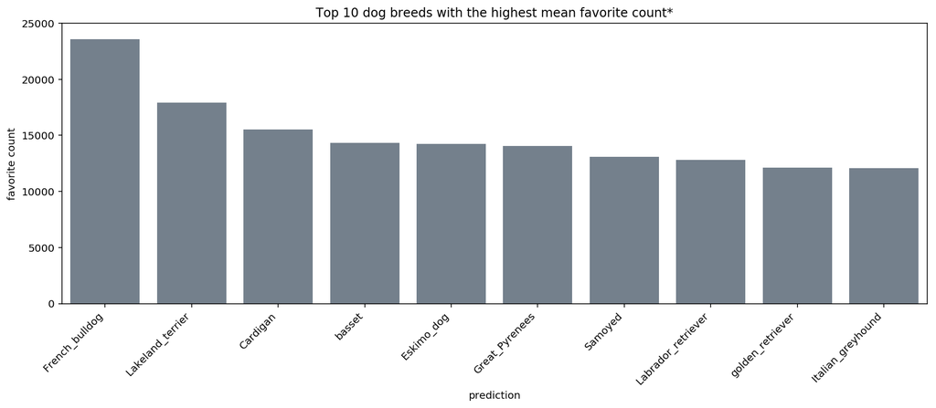

```python
# create a counts df which contains the value counts for each dog breed
counts = top_predictions.prediction.value_counts().rename('counts').reset_index()
counts.columns = ['prediction', 'counts']

# merge the counts df with the top predictions df
top_predictions = pd.merge(top_predictions, counts, on = 'prediction')

# only keep dog breeds where the value count is at least 10.
# this ensures that the the plot is not distorted by breeds for which
# only few datapoints exist.
top_predictions = top_predictions[top_predictions['counts'] >= 10]

# merge top_predictions and archive df to have popularity info and prediction in one table
combined = pd.merge(archive, top_predictions, on = 'tweet_id')
# only consider predictions which depict a dog
combined = combined[combined['dog'] == True]

# group the df by prediction and calculate mean, sort by favorite count descending
combined = combined.groupby('prediction').mean().sort_values('favorite_count', ascending = False).reset_index()

plt.figure(figsize = (15, 5))
sns.barplot(data = combined.head(10), y = 'favorite_count', x = 'prediction', color = base_color)
plt.xticks(rotation = 45, ha = 'right')
plt.ylim(0, 25000)
plt.title('Top 10 dog breeds with the highest mean favorite count*')
plt.ylabel('favorite count');
```

* only dog breeds which are present in at least 10 tweets are considered to avoid distortion.

But dogs do not only come in different breeds, they also evolve through different states in their lifetime. The following graphic explains the different stages:

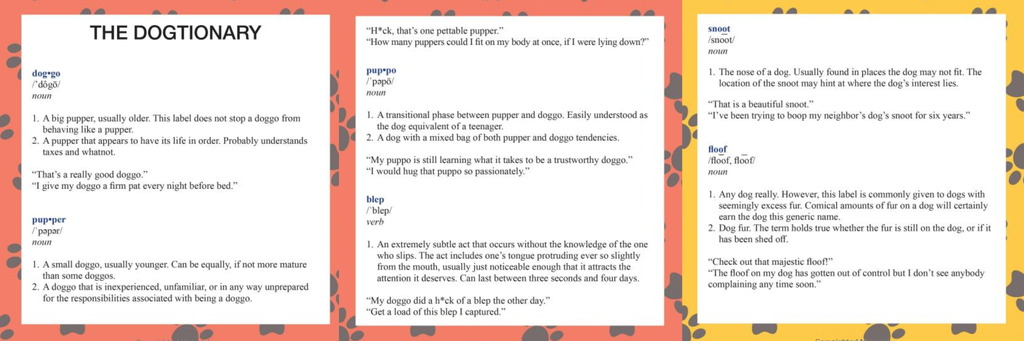

```python
Image('dogtionary-combined.png')
```

### Leading to the third question: what is the most tweeted dog stage?

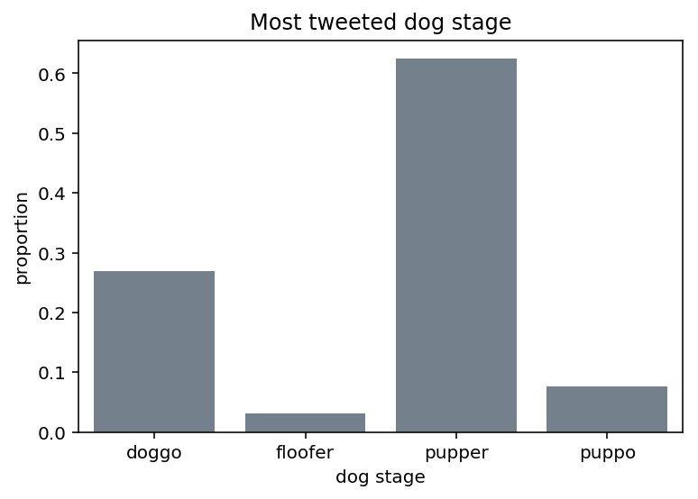

```python
n = archive.dog_stage.count()
n_max = archive.dog_stage.value_counts().max()
p_max = n_max / n
ticks = np.arange(0, p_max, 0.10)
labels = ['{:.1f}'.format(v) for v in ticks]

sns.countplot(data = archive, x = 'dog_stage', color = base_color)
plt.yticks(ticks * n, labels)
plt.ylabel('proportion')
plt.xlabel('dog stage')
plt.title('Most tweeted dog stage');
```

Great, now we know that puppers are with a share of 60 percent the most tweeted dog stage, followed by doggos with around 25 percent. Puppos and floofers are a lot rarer with each one making up less than 10 percent of all tweets. (Side note: it has to be mentioned that the dog stage was only specified in 290 tweets. The above plot is a representation of this sample of 290 tweets).

But what about the popularity of different dog stages? Do the more frequent stages pupper and doggo also get more favorites and retweets?

### What are the most popular dog stages?

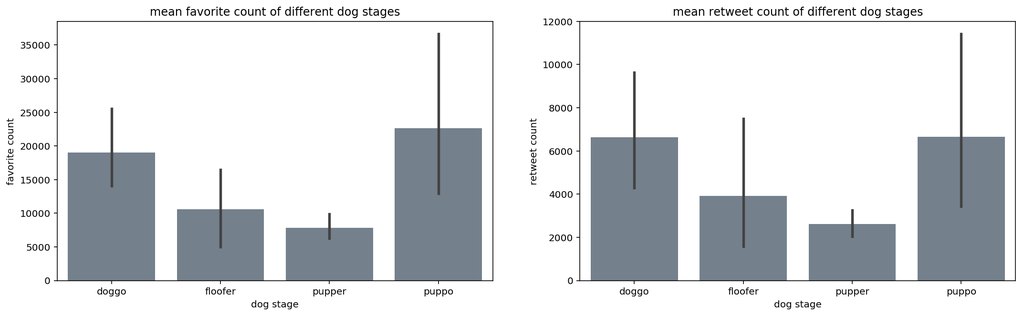

```python
plt.figure(figsize=(18, 5))

plt.subplot(1, 2, 1)
sns.barplot(data = archive, x = 'dog_stage', y = 'favorite_count',\
            color = base_color)
plt.ylabel('favorite count')
plt.xlabel('dog stage')
plt.title('mean favorite count of different dog stages');

plt.subplot(1, 2, 2)
sns.barplot(data = archive, x = 'dog_stage', y = 'retweet_count',\
            color = base_color)
plt.ylabel('retweet count')
plt.xlabel('dog stage')
plt.title('mean retweet count of different dog stages');
```

The [rating system](https://knowyourmeme.com/memes/theyre-good-dogs-brent) is another interesting characteristic to take it closer look at as it is what makes WeRateDogs stand out from other accounts. Each dog receives a rating between 10 and 14 with more being better. Leading to the next question:

### Does a high rating increase the likelihood of a tweet to be more popular?

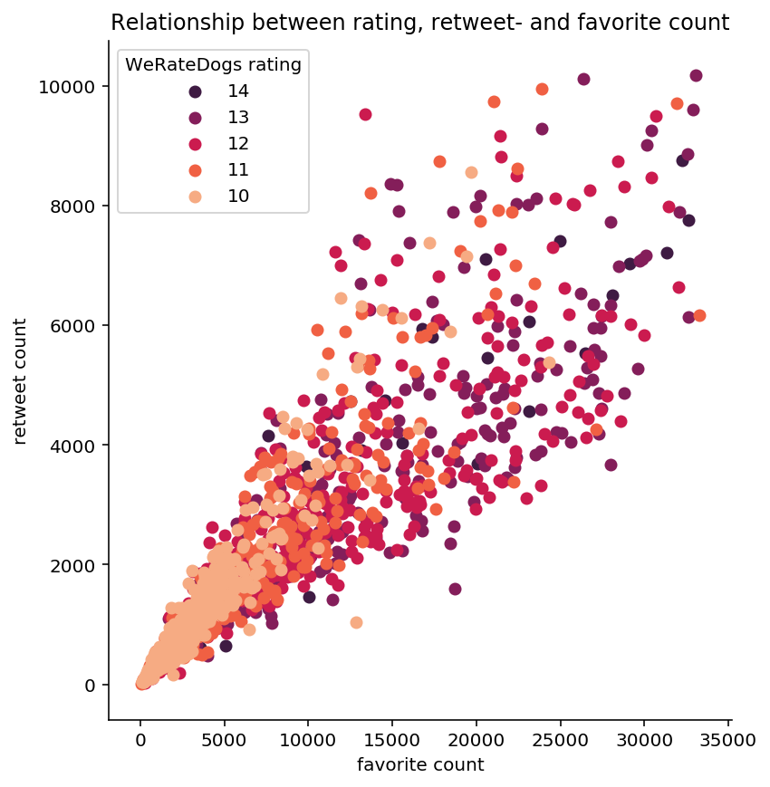

```python
# only plot 95 percentile
data = archive.query('favorite_count < 33302.75 and retweet_count < 10281')

g = sns.FacetGrid(data = data, hue = 'rating_numerator', size = 6,\
                  hue_order = [14, 13, 12, 11, 10], palette = 'rocket')
g.map(plt.scatter, 'favorite_count', 'retweet_count')
plt.xlabel('favorite count')
plt.ylabel('retweet count')
plt.title('Relationship between rating, retweet- and favorite count')
plt.legend(title = 'WeRateDogs rating');
```

First of all, the scatter plot indicates a positive correlation between retweet- and favorite count, meaning that a more favorited tweet is likely to also have a higher retweet count. Second, tweets which receive a higher rating by WeRateDogs tend to be more skewed to the top right indicating that high rated tweets are more likely to go viral.

Let's facet the above plot to get a better understanding of the composition.

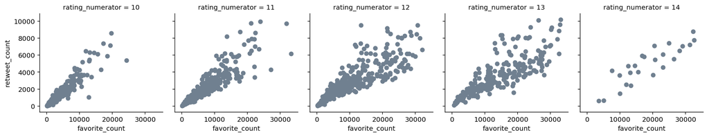

```python
g = sns.FacetGrid(data = data, col = 'rating_numerator')
g.map(plt.scatter, 'favorite_count', 'retweet_count', color = base_color);
```

Now clearly visible is the dispersion of data points towards the top right with the rating increasing. With a rating of 10, the datapoints are skewed towards the bottom left corner whereas datapoints are far more centered and stretch all the way to the top right corner for a rating of 13. Only very few tweets actually receive a rating of 14, indicated by the small amount of datapoints.

So far we have seen the influence of a dogs breed, its stage and the received rating. But the tweets were collected over a period of almost 2 years. So how did different metrics change over time?

### How did the WeRateDogs average favorite-, retweet- and follower count evolve over time?

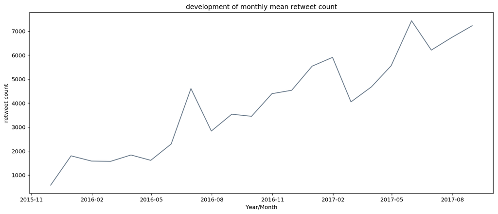

```python
groupby_month = archive.groupby(pd.Grouper(key = 'timestamp', freq = 'M'))\
                [['retweet_count', 'favorite_count', 'followers_count']].mean().reset_index()

plt.figure(figsize = (15, 6))
plt.plot(groupby_month.timestamp, groupby_month.retweet_count, color = base_color)
plt.title('development of monthly mean retweet count')
plt.ylabel('retweet count')
plt.xlabel('Year/Month');
```

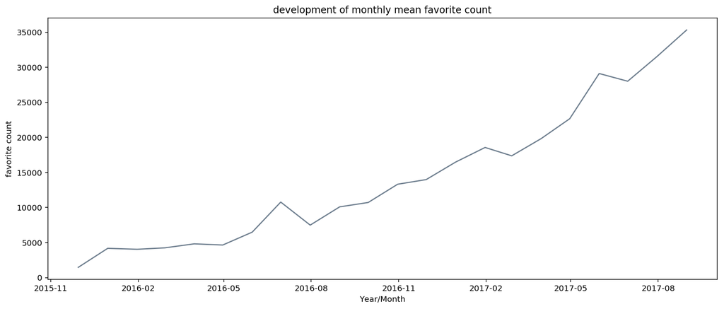

```python
plt.figure(figsize = (15, 6))
plt.plot(groupby_month.timestamp, groupby_month.favorite_count, color = base_color)
plt.title('development of monthly mean favorite count')
plt.ylabel('favorite count')
plt.xlabel('Year/Month');
```

The development of the average favorite count is somewhat similar to that of the average retweet count.

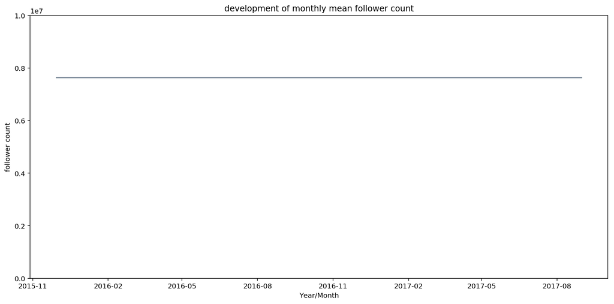

```python
plt.figure(figsize = (15, 7))
plt.plot(groupby_month.timestamp, groupby_month.followers_count, color = base_color)
plt.ylim(0, 10000000)
plt.title('development of monthly mean follower count')
plt.ylabel('follower count')
plt.xlabel('Year/Month');
```

In contrast to the above plots, the follower count of WeRateDogs did not change at all over the queried time period. This is not exactly what I expected as intuition makes me think that favorite and retweet count should be somewhat proportional to follower count.

### Coming to an end, let's have a look at the most popular tweets

```python
top5_index = archive.favorite_count.nlargest(5).index # get index of top 5 tweets
top5 = archive[['tweet_id', 'rating_numerator', 'dog_stage', 'favorite_count',\
                'retweet_count', 'text']].iloc[top5_index]

top_tweet_ids = top5.tweet_id # get tweet ids of top 5 tweets to query predictions df
top_tweet_ids = list(top_tweet_ids) # convert to list
top5pred = predictions[predictions['tweet_id'].isin(top_tweet_ids)] # query predictions df
top5pred = top5pred[top5pred['confidence_order'] == 1] # only consider top predictions
```

```python
plt_tweet('Top Tweet', 788, 2409)
```

```
Top Tweet
Tweet Text: Here's a doggo realizing you can stand in a pool. 13/10 enlightened af (vid by Tina Conrad)
Favorite count: 164239
Retweet count: 83629
Prediction: Labrador_retriever
```

[figure not shown]

```python
plt_tweet('2nd most popular tweet', 322, 3699)
```

```
2nd most popular tweet
Tweet Text: Here's a super supportive puppo participating in the Toronto  #WomensMarch today. 13/10
Favorite count: 140342
Retweet count: 47683
Prediction: Lakeland_terrier
```

[figure not shown]

```python
plt_tweet('3rd most popular tweet', 414, 3432)
```

```
3rd most popular tweet
Tweet Text: This is Stephan. He just wants to help. 13/10 such a good boy
Favorite count: 126982
Retweet count: 60955
Prediction: Chihuahua
```

[figure not shown]